[figure not shown]

# La sous alimentation dans le monde

ALLARD Emma  
Stage M1 SSD 2020

### Table des matières

- Partie I : Préparation des données
  - Importation des packages
  - Importation de nos données de nos données
- Partie II : A-t-on assez de végétaux pour nourrir la population mondiale ?
  - La place des produits dans la sous alimentation
  - Quelles variables influent sur les pays en sous alimentation ?
  - Comment expliquer la sous alimentation ?
  - Peut-on faire des groupes de pays en sous alimentation ?

# Partie I : Préparation de nos données

Une partie de l'analyse durant mon stage sur la sous alimentation dans le monde a été faite en python. Dans ce document vous trouverez tout les scripts.

Importation des packages

```python
# importation des packages

# Packages pour gérer les dataframes

import pandas as pd
from pandasql import sqldf

# Package pour faire l'ACP
import sklearn
from sklearn.preprocessing import StandardScaler
from sklearn.decomposition import PCA

# Pour gérer toutes les fonctions mathématiques
import numpy as np

# Création de graphique
import matplotlib.pyplot as plt
import seaborn as sns; sns.set()

# Création de modèle linéaire
import statsmodels.formula.api as stats
from statsmodels.formula.api import ols
from sklearn.linear_model import LinearRegression

import statsmodels.formula.api as smf

# Pour la méthode kmeans
from sklearn import cluster

 #librairie pour évaluation des partitions

from sklearn import metrics
```

Préparation de nos données

```python
# Importations des données de fichiers csv
# Table sur la sous alimentation
sousnut=pd.read_csv("sousAli.csv")

# changement des noms des colonnes
sousnut.columns=['Code Area','Area','Sous Nutrition']
# Importation de la table avec tous les "Elements" sur les produits végétaux.
vege=pd.read_csv("vegetaux_Liste.csv")
```

Nous retrouverons, une préparation de nos données au début de chaque partie.

Partie II : A t on assez de nourriture pour nourrir la population mondiale ?

La place des produits dans la sous alimentation

Pour mieux comprendre nos données, nous allons réaliser une ACP " Analyse en composantes principales". Nous allons regarder pour "chaque" produit qu'est ce qui le caractérise. L’Analyse en composantes principales, est une méthode consistant a transformer des variables corrélées en variables décorrélées. Le principe de cette méthode est de transformer une variable en « individus » ( par exemple la variable ‘Area’ est représenté par des individus ( pays )). Pour nous montrer graphiquement vers quelles variables tend chaque pays à l’aide d’un cercle de corrélation.

```python
# Selectionner les 50 pays les plus touchés par la sous nutrition

query=('SELECT * FROM sousnut ORDER BY "Sous Nutrition" desc LIMIT 50;')
paysSousNut=sqldf(query,globals())
# Récuperer les pays qui sont dans notre liste des 50 pays

query=('SELECT * from vege WHERE "Area Code" in(SELECT "Code Area" from paysSousNut);')
vegeSous=sqldf(query,globals())

# Regrouper par items

query=('SELECT "Item",sum("Domestic supply quantity") as "Domestic supply quantity" ,sum("Export Quantity") as "Export Quantity",sum("Fat supply quantity") as "Fat supply quantity",sum("Feed") as "Feed",sum("Food") as "Food",sum("Food supply") as "Food supply",sum("Food supply quantity") as "Food supply quantity",sum("Import Quantity") as "Import Quantity",sum("Losses") as "Losses",sum("Other uses (non-food)") as "other uses",sum("Production") as "production",sum("Protein supply quantity") as "protein supply quantity",sum("Residuals") as "Residuals",sum("Seed") as "Seed",sum("Stock Variation") as "Stock Variation" from vegeSous GROUP BY "Item";')
VegeSous=sqldf(query,globals())



VegeSous.index=VegeSous['Item']
```

```python
# Afficher les 50 pays en sous alimentation
paysSousNut
```

|  | Code | Area | Sous Nutrition |
| --- | --- | --- | --- |
| 0 | 37 | République centrafricaine | 59.6 |
| 1 | 181 | Zimbabwe | 51.3 |
| 2 | 93 | Haïti | 49.3 |
| 3 | 116 | République populaire démocratique de Corée | 47.8 |
| 4 | 251 | Zambie | 46.7 |
| 5 | 129 | Madagascar | 44.4 |
| 6 | 226 | Ouganda | 41.0 |
| 7 | 46 | Congo | 40.3 |
| 8 | 249 | Yémen | 38.9 |
| 9 | 39 | Tchad | 37.5 |
| 10 | 123 | Libéria | 37.2 |
| 11 | 184 | Rwanda | 36.8 |
| 12 | 215 | République-Unie de Tanzanie | 30.7 |
| 13 | 2 | Afghanistan | 29.8 |
| 14 | 114 | Kenya | 29.4 |
| 15 | 103 | Iraq | 29.0 |
| 16 | 175 | Guinée-Bissau | 28.0 |
| 17 | 144 | Mozambique | 27.9 |
| 18 | 147 | Namibie | 27.3 |
| 19 | 20 | Botswana | 26.4 |
| 20 | 197 | Sierra Leone | 25.6 |
| 21 | 7 | Angola | 25.0 |
| 22 | 176 | Timor-Leste | 24.9 |
| 23 | 236 | Venezuela (République bolivarienne du) | 21.2 |
| 24 | 209 | Eswatini | 20.6 |
| 25 | 238 | Éthiopie | 20.6 |
| 26 | 165 | Pakistan | 20.3 |
| 27 | 276 | Soudan | 20.1 |
| 28 | 233 | Burkina Faso | 20.0 |
| 29 | 107 | Côte d'Ivoire | 19.0 |
| 30 | 72 | Djibouti | 18.9 |
| 31 | 130 | Malawi | 17.5 |
| 32 | 19 | Bolivie (État plurinational de) | 17.1 |
| 33 | 157 | Nicaragua | 17.0 |
| 34 | 90 | Guinée | 16.5 |
| 35 | 120 | République démocratique populaire lao | 16.5 |
| 36 | 158 | Niger | 16.5 |
| 37 | 115 | Cambodge | 16.4 |
| 38 | 217 | Togo | 16.1 |
| 39 | 89 | Guatemala | 15.2 |
| 40 | 16 | Bangladesh | 14.7 |
| 41 | 100 | Inde | 14.5 |
| 42 | 141 | Mongolie | 13.4 |
| 43 | 159 | Nigéria | 13.4 |
| 44 | 171 | Philippines | 13.3 |
| 45 | 122 | Lesotho | 13.1 |
| 46 | 95 | Honduras | 12.9 |
| 47 | 35 | Cabo Verde | 12.6 |
| 48 | 112 | Jordanie | 12.2 |
| 49 | 195 | Sénégal | 11.3 |

```python
# Définir une matrice

X=VegeSous
# Nombre obs

n=X.shape[0]

# Nombre variables

p=X.shape[1]

# 75 lignes et 15 colonnes

X.shape
```

```
(75, 16)
```

```python
# supprimer la colonne 'Item'

del VegeSous['Item']
```

```python
sc=StandardScaler()

# transformation, centrée et réduire la matrice

Z=sc.fit_transform(X)


# Faire la moyenne

moy=np.mean(Z,axis=0)

# Afficher l'Ecart-Type

ecart=np.std(Z,axis=0,ddof=0)
```

```python
# Fonction de l'ACP

acp=PCA(svd_solver='full')

# Calcule des coordonnées

coord=acp.fit_transform(Z)

# Valeur corrigée

eigval=(n-1)/n*acp.explained_variance_
print(eigval)

# Correction des valeurs propres
# Nous avons 3 valeurs propres > 1. Nous allons prendre 3 axes.
```

```
[7.25929107e+00 2.58730275e+00 1.70320710e+00 9.60721331e-01
 9.11053057e-01 5.69555537e-01 3.91124309e-01 3.41157125e-01
 1.49145376e-01 5.90254324e-02 3.22125180e-02 2.04733628e-02
 1.02918305e-02 5.43630709e-03 2.90583882e-06]
```

Nous avons 3 valeurs propres supérieures à 1. Nous pouvons alors nous poser la question de choisir 3 axes.

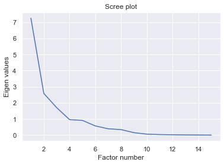

```python
# Création des graphiques
#Scree plot


plt.plot(np.arange(1,p),eigval)
plt.title("Scree plot")
plt.ylabel("Eigen values")
plt.xlabel("Factor number")
plt.show()
```

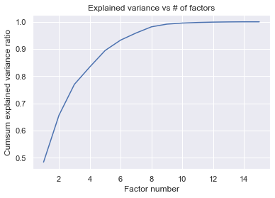

```python
# Cumul de variance expliquée

plt.plot(np.arange(1,p),np.cumsum(acp.explained_variance_ratio_))
plt.title("Explained variance vs # of factors")
plt.ylabel("Cumsum explained variance ratio")
plt.xlabel("Factor number")
plt.show()
```

Avec nos graphiques, on voit que le "coude" est à 3. Nous choisissons alors 3 axes.

```python
# Seuils pour tests des batons brisés

bs=1/np.arange(p,0,-1)
bs=np.cumsum(bs)
bs=bs[::-1]
```

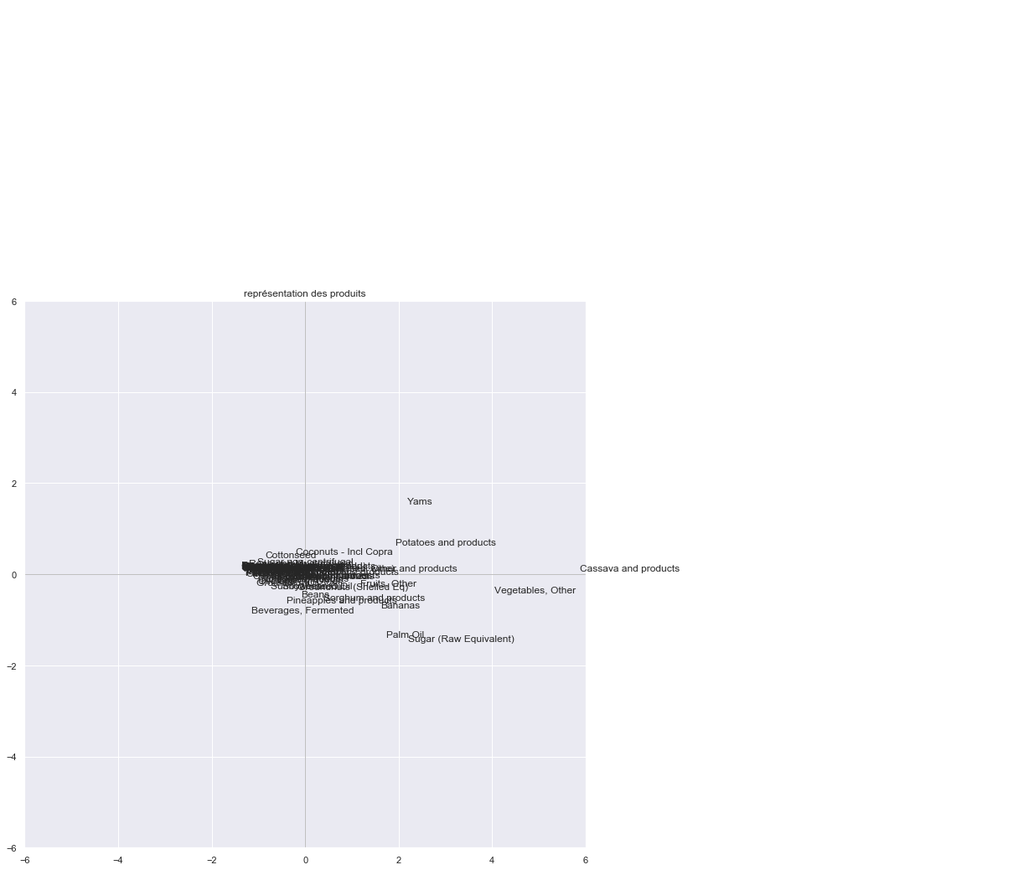

```python
# positionnement des individus dans le premier plan

fig,axes=plt.subplots(figsize=(12,12))
axes.set_xlim(-6,6)
axes.set_ylim(-6,6)

# placement des etiquettes des obs
for i in range(n):
    plt.annotate(X.index[i],(coord[i,0],coord[i,1]))

# ajouter les axes

plt.plot([-6,6],[0,0],color='silver',linestyle='-',linewidth=1)
plt.plot([0,0],[-6,6],color='silver',linestyle='-',linewidth=1)

#affichage
plt.title("représentation des produits")
plt.show()
```

**Contribution des individus dans l'intertie totale**

```python
di=np.sum(Z**2,axis=1)
print(pd.DataFrame({'ID': X.index,'d_i':di}))
```

```
                       ID         d_i
0       Alcohol, Non-Food    1.988381
1     Apples and products    1.451010
2                 Bananas   26.356021
3     Barley and products    1.379704
4                   Beans    2.286067
..                    ...         ...
70  Tomatoes and products    0.910762
71      Vegetables, Other   45.310316
72     Wheat and products  134.904864
73                   Wine    1.900930
74                   Yams   31.268851

[75 rows x 2 columns]
```

**Qualité de représentation des individus - COS2**

```python
cos2=coord**2
for j in range(p-1):
    cos2[:,j]=cos2[:,j]/di


print(pd.DataFrame({'id':X.index,'COS2_1':cos2[:,0],'COS2_2':cos2[:,1]}))
```

```
                       id    COS2_1        COS2_2
0       Alcohol, Non-Food  0.453345  1.291430e-02
1     Apples and products  0.883382  1.485934e-03
2                 Bananas  0.099495  2.072290e-02
3     Barley and products  0.833910  5.152103e-03
4                   Beans  0.003793  1.074527e-01
..                    ...       ...           ...
70  Tomatoes and products  0.069297  7.705819e-08
71      Vegetables, Other  0.360325  3.502223e-03
72     Wheat and products  0.695361  3.657311e-02
73                   Wine  0.923117  6.098702e-03
74                   Yams  0.152661  7.568477e-02

[75 rows x 3 columns]
```

**Contribution aux axes**

```python
ctr=coord**2
for j in range(p-1):
    ctr[:,j]=ctr[:,j]/(n*eigval[j])

print(pd.DataFrame({'id':X.index,'CTR_1':ctr[:,0],'CTR_2':ctr[:,1]}))
```

```
                       id     CTR_1         CTR_2
0       Alcohol, Non-Food  0.001656  1.323310e-04
1     Apples and products  0.002354  1.111121e-05
2                 Bananas  0.004816  2.814634e-03
3     Barley and products  0.002113  3.663212e-05
4                   Beans  0.000016  1.265896e-03
..                    ...       ...           ...
70  Tomatoes and products  0.000116  3.616723e-10
71      Vegetables, Other  0.029987  8.177723e-04
72     Wheat and products  0.172299  2.542618e-02
73                   Wine  0.003223  5.974411e-05
74                   Yams  0.008768  1.219585e-02

[75 rows x 3 columns]
```

```python
# Racine carré des valeurs propres

sqrt_eigval=np.sqrt(eigval)
```

```python
# Corrélation des variables avec les axes

corvar=np.zeros((p-1,p-1))

for k in range(p-1):
    corvar[:,k]=acp.components_[k,:]*sqrt_eigval[k]
```

**Affichage du cercle de corrélation**

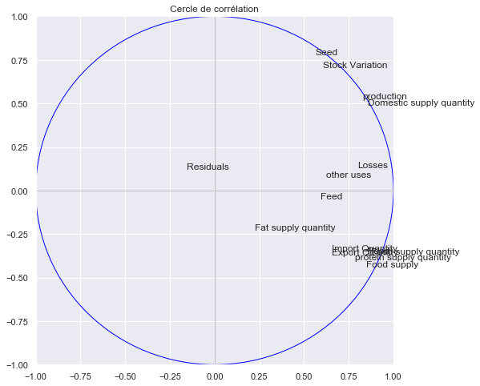

```python
# cercle des corrélations

fig,axes=plt.subplots(figsize=(8,8))
axes.set_xlim(-1,1)
axes.set_ylim(-1,1)

for j in range(p-1):
    plt.annotate(X.columns[j],(corvar[j,0],corvar[j,1]))

plt.plot([-1,1],[0,0],color='silver',linestyle='-',linewidth=1)
plt.plot([0,0],[-1,1],color='silver',linestyle='-',linewidth=1)

#Ajout du cercle
cercle = plt.Circle((0,0),1,color='blue',fill=False)
axes.add_artist(cercle)

#affichage

plt.title("Cercle de corrélation")
plt.show()
```

Analyse de l'ACP, Nous retrouvons la variable "Fat supply quantity" qui est corrélée positivement avec les aliments. Nous voyons qu'il y a Import, Export et toutes les quantité de disponibilité alimentaires sont fortement corrélés.

Les pommes de terres et le manioc sont prochent des variables "seed", stock variation et production. Ce sont des produits qui coûtent peu chers et qui poussent trés facilement. L'huile de palme et le sucre sont des produits qui sont énormément exportés et importés. Avec beaucoup de matières grasses. Ce sont des produits qui contiennent beaucoup de kcalories.

Quelles variables caractérisent les pays en sous alimentation?

Pour cette ACP, nous reprenons les mêmes bases de données mais cette fois on étudie les pays et non les variables.

```python
# Grouper les données par les pays
query=('SELECT "Area",sum("Domestic supply quantity") as "Domestic supply quantity" ,sum("Export Quantity") as "Export Quantity",sum("Fat supply quantity") as "Fat supply quantity",sum("Feed") as "Feed",sum("Food") as "Food",sum("Food supply") as "Food supply",sum("Food supply quantity") as "Food supply quantity",sum("Import Quantity") as "Import Quantity",sum("Losses") as "Losses",sum("Other uses (non-food)") as "other uses",sum("Production") as "production",sum("Protein supply quantity") as "protein supply quantity",sum("Residuals") as "Residuals",sum("Seed") as "Seed",sum("Stock Variation") as "Stock Variation" from vegeSous GROUP BY "Area Code";')
VegeSous=sqldf(query,globals())

VegeSous.head()
```

|  | Area | Domestic supply quantity | Export Quantity | Fat supply quantity | Feed | Food | Food supply | Food supply quantity | Import Quantity | Losses | other uses | production | protein supply quantity | Residuals | Seed | Stock Variation |
| --- | --- | --- | --- | --- | --- | --- | --- | --- | --- | --- | --- | --- | --- | --- | --- | --- |
| 0 | Afghanistan | 12432 | 601 | 17.75 | 345 | 10577 | 1867 | 297.17 | 4389 | 1196 | 152 | 9737 | 43.91 | -111 | 583 | 426 |
| 1 | Angola | 30424 | 16 | 34.03 | 6813 | 15383 | 2095 | 519.36 | 3397 | 3914 | 613 | 28047 | 37.86 | -2 | 543 | 403 |
| 2 | Bangladesh | 94359 | 191 | 27.28 | 7451 | 68996 | 2488 | 434.97 | 17918 | 4881 | 7038 | 81018 | 48.37 | -121 | 1699 | 3870 |
| 3 | Bolivia (Plurinational State of) | 26768 | 672 | 22.55 | 2503 | 4797 | 1910 | 429.80 | 1118 | 1020 | 5758 | 19053 | 37.52 | -3 | 941 | -7623 |
| 4 | Botswana | 1042 | 14 | 42.89 | 70 | 857 | 1978 | 383.00 | 845 | 208 | 81 | 986 | 38.76 | 101 | 140 | 144 |

```python
# Mettre les pays en index

VegeSous.index=VegeSous['Area']
del VegeSous['Area']
```

Nous créons X notre matrice, pour faire notre ACP pour simplifier les résultats.

```python
X=VegeSous

# Nombre obs

n=X.shape[0]

# Nombre variables

p=X.shape[1]

# 50 lignes et 16 colonnes
```

```python
# transformation,centrée réduite

Z=sc.fit_transform(X)
np.mean(Z,axis=0)
np.std(Z,axis=0,ddof=0)
```

```
array([1., 1., 1., 1., 1., 1., 1., 1., 1., 1., 1., 1., 1., 1., 1.])
```

```python
# Calcul des coordonnées


coord=acp.fit_transform(Z)

# Nombre de composantes calculées

print(acp.n_components_) # 15
```

```
15
```

```python
# Variance expliquée

print(acp.explained_variance_)

# Valeur corrigée

eigval=(n-1)/n*acp.explained_variance_
print(eigval)

# Correction des valeurs propres

print(acp.singular_values_**2/n)
```

```
[8.95166228e+00 2.24519170e+00 1.35223785e+00 8.61845363e-01
 7.17571171e-01 6.09636525e-01 2.58816510e-01 1.62765192e-01
 6.07083963e-02 4.38053483e-02 3.30625816e-02 6.55304350e-03
 1.96329647e-03 3.02592782e-04 5.94960095e-07]
[8.77262904e+00 2.20028787e+00 1.32519309e+00 8.44608456e-01
 7.03219747e-01 5.97443795e-01 2.53640180e-01 1.59509888e-01
 5.94942284e-02 4.29292413e-02 3.24013299e-02 6.42198263e-03
 1.92403055e-03 2.96540926e-04 5.83060893e-07]
[8.77262904e+00 2.20028787e+00 1.32519309e+00 8.44608456e-01
 7.03219747e-01 5.97443795e-01 2.53640180e-01 1.59509888e-01
 5.94942284e-02 4.29292413e-02 3.24013299e-02 6.42198263e-03
 1.92403055e-03 2.96540926e-04 5.83060893e-07]
```

```python
## Proportion de variance expliquée

print(acp.explained_variance_ratio_)
```

```
[5.84841936e-01 1.46685858e-01 8.83462062e-02 5.63072304e-02
 4.68813165e-02 3.98295863e-02 1.69093453e-02 1.06339926e-02
 3.96628189e-03 2.86194942e-03 2.16008866e-03 4.28132175e-04
 1.28268703e-04 1.97693951e-05 3.88707262e-08]
```

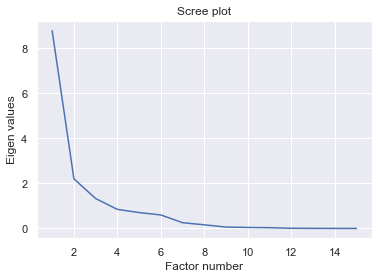

```python
# Création des graphiques
#Scree plot Importation du package pour les plot
import matplotlib.pyplot as plt

plt.plot(np.arange(1,p+1),eigval)
plt.title("Scree plot")
plt.ylabel("Eigen values")
plt.xlabel("Factor number")
plt.show()
```

Le coude étant à "2", on retient 2 dimensions.

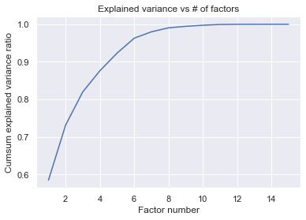

```python
# Cumul de variance expliquée

plt.plot(np.arange(1,p+1),np.cumsum(acp.explained_variance_ratio_))
plt.title("Explained variance vs # of factors")
plt.ylabel("Cumsum explained variance ratio")
plt.xlabel("Factor number")
plt.show()


#Avec cela on voit le coude à 2, donc on retient 2 dimensions.
```

```python
# Seuils pour tests des batons brisés

bs=1/np.arange(p,0,-1)
bs=np.cumsum(bs)
bs=bs[::-1]

# D'après le Critère de Kaiser : L'axe dont l'inertie est > à 1

# Les 3 premières valeurs propres sont > à 1.

print(pd.DataFrame({'Val.Propre':eigval,'Seuils':bs}))
```

```
      Val.Propre    Seuils
0   8.772629e+00  3.318229
1   2.200288e+00  2.318229
2   1.325193e+00  1.818229
3   8.446085e-01  1.484896
4   7.032197e-01  1.234896
5   5.974438e-01  1.034896
6   2.536402e-01  0.868229
7   1.595099e-01  0.725372
8   5.949423e-02  0.600372
9   4.292924e-02  0.489261
10  3.240133e-02  0.389261
11  6.421983e-03  0.298352
12  1.924031e-03  0.215018
13  2.965409e-04  0.138095
14  5.830609e-07  0.066667
```

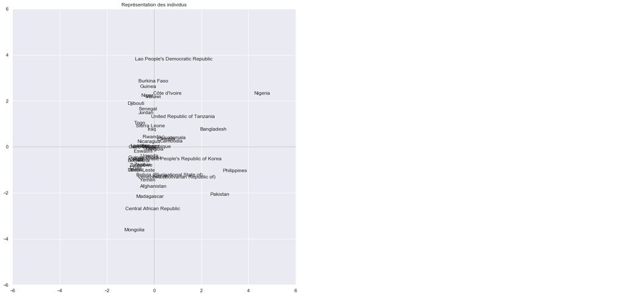

```python
# positionnement des individus dans le premier plan

fig,axes=plt.subplots(figsize=(12,12))
axes.set_xlim(-6,6)
axes.set_ylim(-6,6)

# placement des etiquettes des obs
for i in range(n):
    plt.annotate(X.index[i],(coord[i,0],coord[i,1]))

# ajouter les axes

plt.plot([-6,6],[0,0],color='silver',linestyle='-',linewidth=1)
plt.plot([0,0],[-6,6],color='silver',linestyle='-',linewidth=1)

#affichage

plt.title("Représentation des individus")
plt.show()
```

Nous avons un groupe avec L'Afrique Centrale, la Mongolie. Que nous retrouvons dans beaucoup de nos analyses. Un deuxième groupe avec les Philippines et le Pakistan. Et un troisième avec le Nigéria, Bangladesh.

```python
# Contribution des individus dans l'intertie totale

di=np.sum(Z**2,axis=1)
```

```python
# Qualité de représentation des individus - COS2

cos2=coord**2
for j in range(p):
    cos2[:,j]=cos2[:,j]/di
```

```python
ctr=coord**2
for j in range(p):
    ctr[:,j]=ctr[:,j]/(n*eigval[j])
```

```python
# Racine carré des valeurs propres

sqrt_eigval=np.sqrt(eigval)
```

```python
# Corrélation des variables avec les axes

corvar=np.zeros((p,p))

for k in range(p):
    corvar[:,k]=acp.components_[k,:]*sqrt_eigval[k]
```

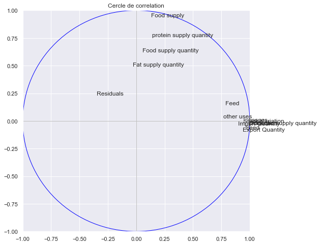

```python
# cercle des corrélations

fig,axes=plt.subplots(figsize=(8,8))
axes.set_xlim(-1,1)
axes.set_ylim(-1,1)

for j in range(p):
    plt.annotate(X.columns[j],(corvar[j,0],corvar[j,1]))

plt.plot([-1,1],[0,0],color='silver',linestyle='-',linewidth=1)
plt.plot([0,0],[-1,1],color='silver',linestyle='-',linewidth=1)

#Ajout du cercle
cercle = plt.Circle((0,0),1,color='blue',fill=False)
axes.add_artist(cercle)

#affichage

plt.title("Cercle de correlation")
plt.show()
```

Nous voyons que l'Afrique Centrale et la Mongolie sont corrélés négativement avec toutes les quantités disponibilités alimentaire. L'Afrique centrale est le pays le plus touché par la sous alimentation. Et la Mongolie reste le pays avec le moins de disponibilité alimentaire ( moins de 1400 kcal/jour). Le groupe du Nigéria et du Bangladesh reste les moins touchés " des 50 pays les plus touchés " par la sous alimentation.

Quels facteurs influents la sous alimentation ?

Pour mieux comprendre la sous alimentation et l'expliquer, nous créons un modèle linéaire en prenant compte les corrélations, les premières analyses mais aussi ce que nous savons sur le sujet.

En statistiques, le modèle de régression linéaire est un modèle pour prédire et expliquer une variable quantitative ( pour nous ce sera la sous alimentation ). L’objectif est d’établir un lien entre la sous alimentation et les autres variables. Pour voir l’influence des variables, si elles augmentent ou diminuent la sous alimentation.

```python
# Import des données

vegeListe=pd.read_csv("vegetaux_Liste.csv")
partTerre=pd.read_csv("partTerre.csv")
stabpol=pd.read_csv("stabPol.csv")
pop=pd.read_csv("populationres.csv")
PIB=pd.read_csv("PIB.csv")
```

```python
# Supprimer la colonne Element de la table stabpol
del stabpol['Element']

# Renommer les colonnes de la table stabpol

stabpol.columns=['Area Code','Area','personne','stab']
```

```python
# Grouper la table vegeListe par pays grâce aux requêtes SQL

query=('SELECT * FROM vegeListe GROUP BY Area;')
vegetot=sqldf(query,globals())

vegetot.head()
```

|  | Area Code | Area | Item Code | Item | Domestic supply quantity | Export Quantity | Fat supply quantity | Feed | Food | Food supply | ... | Import Quantity | Losses | Other uses (non-food) | Processing | Production | Protein supply quantity | Residuals | Seed | Stock Variation | Tourist consumption |
| --- | --- | --- | --- | --- | --- | --- | --- | --- | --- | --- | --- | --- | --- | --- | --- | --- | --- | --- | --- | --- | --- |
| 0 | 2 | Afghanistan | 2511 | Wheat and products | 6701 | 0 | 4.47 | 76 | 5640 | 1331 | ... | 2302 | 642 | 1 | 4 | 4281 | 35.88 | 0 | 344 | -119 | 0 |
| 1 | 3 | Albania | 2511 | Wheat and products | 580 | 4 | 6.09 | 20 | 381 | 1019 | ... | 295 | 27 | 137 | 0 | 275 | 32.28 | 0 | 15 | -13 | 0 |
| 2 | 4 | Algeria | 2511 | Wheat and products | 10532 | 10 | 5.24 | 957 | 7685 | 1427 | ... | 8105 | 736 | 1030 | 0 | 2437 | 43.08 | -6 | 130 | 0 | 0 |
| 3 | 7 | Angola | 2511 | Wheat and products | 972 | 0 | 0.90 | 1 | 972 | 239 | ... | 1176 | 0 | 1 | 0 | 3 | 7.16 | -1 | 0 | 207 | 0 |
| 4 | 8 | Antigua and Barbuda | 2511 | Wheat and products | 8 | 0 | 4.84 | 0 | 6 | 504 | ... | 9 | 3 | 0 | 0 | 0 | 13.46 | 0 | 2 | 1 | 2 |

5 rows × 21 columns

```python
# Tri de la table population
# Selectionner les populations des pays qui sont présents
# dans la table vegetot

query=('SELECT * from pop WHERE Area in(SELECT Area from vegetot);')
poptot=sqldf(query,globals())

poptot.head()

# Tri de la table PIB
# Changer les noms des colonnes

PIB.columns=['Area Code','Area','PIB']


PIB['PIB']=PIB['PIB']*1000000
```

```python
PIB.head()


query=('SELECT * from PIB,poptot where PIB.Area==poptot.Area;')
PIB=sqldf(query,globals())

PIB['PIB']=PIB['PIB']/PIB['population_totale']
```

```python
del PIB['population_totale']
```

```python
# Création de la dataframe

query=('SELECT * from vegetot,PIB,stabpol,poptot,partTerre WHERE vegetot.Area==PIB.Area AND vegetot.Area==stabpol.Area AND vegetot.Area==partTerre.Area AND vegetot.Area==poptot.Area')
df=sqldf(query,globals())
df.head()
```

|  | Area Code | Area | Item Code | Item | Domestic supply quantity | Export Quantity | Fat supply quantity | Feed | Food | Food supply | ... | PIB | Code | Area | Nombre | stab | Area | population_totale | Area Code | Area | Part agricole |
| --- | --- | --- | --- | --- | --- | --- | --- | --- | --- | --- | --- | --- | --- | --- | --- | --- | --- | --- | --- | --- | --- |
| 0 | 2 | Afghanistan | 2511 | Wheat and products | 6701 | 0 | 4.47 | 76 | 5640 | 1331 | ... | 48.448714 | 2 | Afghanistan | 10.6 | -2.78 | Afghanistan | 36296113 | 2 | Afghanistan | 58.07 |
| 1 | 3 | Albania | 2511 | Wheat and products | 580 | 4 | 6.09 | 20 | 381 | 1019 | ... | 4092.443959 | 3 | Albania | 0.2 | 0.40 | Albania | 2884169 | 3 | Albania | 42.67 |
| 2 | 4 | Algeria | 2511 | Wheat and products | 10532 | 10 | 5.24 | 957 | 7685 | 1427 | ... | 335.263878 | 4 | Algeria | 1.6 | -0.96 | Algeria | 41389189 | 4 | Algeria | 17.35 |
| 3 | 7 | Angola | 2511 | Wheat and products | 972 | 0 | 0.90 | 1 | 972 | 239 | ... | 202.738285 | 7 | Angola | 7.4 | -0.29 | Angola | 29816766 | 7 | Angola | 47.50 |
| 4 | 8 | Antigua and Barbuda | 2511 | Wheat and products | 8 | 0 | 4.84 | 0 | 6 | 504 | ... | 239512.292247 | 8 | Antigua and Barbuda | 0.0 | 0.76 | Antigua and Barbuda | 95426 | 8 | Antigua and Barbuda | 20.45 |

5 rows × 33 columns

```python
# Suppression des colonnes inutiles

del df['Area Code']
del df['Area']
del df['Item Code']
del df['Item']
del df['Tourist consumption']
del df['Seed']
del df['Processing']
del df['Code']
```

```python
# Renommer les colonnes

df.columns=['domestic','Export','Fat','Feed','Food','Food_supply','Food_quantity','Import','Losses','Other_use','Production','Protein','Resi','Stock','PIB','Personne','Stab','Poptot','Partagricole']
```

```python
# Affichage de la dataframe

df.head()
```

|  | domestic | Export | Fat | Feed | Food | Food_supply | Food_quantity | Import | Losses | Other_use | Production | Protein | Resi | Stock | PIB | Personne | Stab | Poptot | Partagricole |
| --- | --- | --- | --- | --- | --- | --- | --- | --- | --- | --- | --- | --- | --- | --- | --- | --- | --- | --- | --- |
| 0 | 6701 | 0 | 4.47 | 76 | 5640 | 1331 | 155.39 | 2302 | 642 | 1 | 4281 | 35.88 | 0 | -119 | 48.448714 | 10.6 | -2.78 | 36296113 | 58.07 |
| 1 | 580 | 4 | 6.09 | 20 | 381 | 1019 | 132.10 | 295 | 27 | 137 | 275 | 32.28 | 0 | -13 | 4092.443959 | 0.2 | 0.40 | 2884169 | 42.67 |
| 2 | 10532 | 10 | 5.24 | 957 | 7685 | 1427 | 185.67 | 8105 | 736 | 1030 | 2437 | 43.08 | -6 | 0 | 335.263878 | 1.6 | -0.96 | 41389189 | 17.35 |
| 3 | 972 | 0 | 0.90 | 1 | 972 | 239 | 32.60 | 1176 | 0 | 1 | 3 | 7.16 | -1 | 207 | 202.738285 | 7.4 | -0.29 | 29816766 | 47.50 |
| 4 | 8 | 0 | 4.84 | 0 | 6 | 504 | 59.42 | 9 | 3 | 0 | 0 | 13.46 | 0 | 1 | 239512.292247 | 0.0 | 0.76 | 95426 | 20.45 |

```python
# on regarde la corrélation des variables

df.corr(method='spearman').style.format("{:.2}").background_gradient(cmap=plt.get_cmap('coolwarm'))

# il faut rajouter la légende
```

|  | domestic | Export | Fat | Feed | Food | Food_supply | Food_quantity | Import | Losses | Other_use | Production | Protein | Resi | Stock | PIB | Personne | Stab | Poptot | Partagricole |
| --- | --- | --- | --- | --- | --- | --- | --- | --- | --- | --- | --- | --- | --- | --- | --- | --- | --- | --- | --- |
| domestic | 1.0 | 0.69 | 0.14 | 0.84 | 0.98 | 0.39 | 0.43 | 0.8 | 0.77 | 0.6 | 0.76 | 0.41 | -0.32 | 0.15 | -0.48 | 0.16 | -0.27 | 0.8 | 0.27 |
| Export | 0.69 | 1.0 | 0.14 | 0.65 | 0.61 | 0.31 | 0.36 | 0.47 | 0.56 | 0.48 | 0.62 | 0.34 | -0.29 | 0.078 | -0.07 | -0.2 | 0.17 | 0.44 | 0.16 |
| Fat | 0.14 | 0.14 | 1.0 | 0.24 | 0.11 | 0.84 | 0.81 | 0.0098 | 0.3 | 0.18 | 0.33 | 0.83 | -0.05 | -0.033 | 0.52 | -0.5 | 0.28 | -0.29 | -0.15 |
| Feed | 0.84 | 0.65 | 0.24 | 1.0 | 0.75 | 0.42 | 0.46 | 0.63 | 0.71 | 0.61 | 0.75 | 0.45 | -0.27 | 0.12 | -0.2 | -0.12 | -0.027 | 0.55 | 0.18 |
| Food | 0.98 | 0.61 | 0.11 | 0.75 | 1.0 | 0.36 | 0.4 | 0.82 | 0.72 | 0.54 | 0.69 | 0.39 | -0.33 | 0.17 | -0.56 | 0.26 | -0.35 | 0.85 | 0.25 |
| Food_supply | 0.39 | 0.31 | 0.84 | 0.42 | 0.36 | 1.0 | 0.99 | 0.19 | 0.5 | 0.3 | 0.53 | 0.99 | -0.11 | -0.054 | 0.35 | -0.43 | 0.15 | -0.063 | -0.0018 |
| Food_quantity | 0.43 | 0.36 | 0.81 | 0.46 | 0.4 | 0.99 | 1.0 | 0.23 | 0.52 | 0.33 | 0.55 | 0.99 | -0.12 | -0.055 | 0.32 | -0.43 | 0.14 | -0.025 | 0.019 |
| Import | 0.8 | 0.47 | 0.0098 | 0.63 | 0.82 | 0.19 | 0.23 | 1.0 | 0.48 | 0.42 | 0.41 | 0.23 | -0.3 | 0.24 | -0.46 | 0.22 | -0.28 | 0.72 | 0.18 |
| Losses | 0.77 | 0.56 | 0.3 | 0.71 | 0.72 | 0.5 | 0.52 | 0.48 | 1.0 | 0.53 | 0.79 | 0.51 | -0.2 | 0.11 | -0.22 | -0.044 | -0.11 | 0.5 | 0.16 |
| Other_use | 0.6 | 0.48 | 0.18 | 0.61 | 0.54 | 0.3 | 0.33 | 0.42 | 0.53 | 1.0 | 0.58 | 0.33 | -0.26 | 0.14 | -0.13 | -0.076 | 0.016 | 0.4 | 0.067 |
| Production | 0.76 | 0.62 | 0.33 | 0.75 | 0.69 | 0.53 | 0.55 | 0.41 | 0.79 | 0.58 | 1.0 | 0.54 | -0.22 | 0.033 | -0.19 | -0.12 | -0.047 | 0.48 | 0.25 |
| Protein | 0.41 | 0.34 | 0.83 | 0.45 | 0.39 | 0.99 | 0.99 | 0.23 | 0.51 | 0.33 | 0.54 | 1.0 | -0.12 | -0.04 | 0.33 | -0.43 | 0.15 | -0.039 | 0.0045 |
| Resi | -0.32 | -0.29 | -0.05 | -0.27 | -0.33 | -0.11 | -0.12 | -0.3 | -0.2 | -0.26 | -0.22 | -0.12 | 1.0 | -0.19 | 0.17 | -0.1 | 0.13 | -0.28 | 0.068 |
| Stock | 0.15 | 0.078 | -0.033 | 0.12 | 0.17 | -0.054 | -0.055 | 0.24 | 0.11 | 0.14 | 0.033 | -0.04 | -0.19 | 1.0 | -0.2 | 0.16 | -0.15 | 0.2 | 0.084 |
| PIB | -0.48 | -0.07 | 0.52 | -0.2 | -0.56 | 0.35 | 0.32 | -0.46 | -0.22 | -0.13 | -0.19 | 0.33 | 0.17 | -0.2 | 1.0 | -0.79 | 0.73 | -0.85 | -0.36 |
| Personne | 0.16 | -0.2 | -0.5 | -0.12 | 0.26 | -0.43 | -0.43 | 0.22 | -0.044 | -0.076 | -0.12 | -0.43 | -0.1 | 0.16 | -0.79 | 1.0 | -0.7 | 0.56 | 0.27 |
| Stab | -0.27 | 0.17 | 0.28 | -0.027 | -0.35 | 0.15 | 0.14 | -0.28 | -0.11 | 0.016 | -0.047 | 0.15 | 0.13 | -0.15 | 0.73 | -0.7 | 1.0 | -0.51 | -0.27 |
| Poptot | 0.8 | 0.44 | -0.29 | 0.55 | 0.85 | -0.063 | -0.025 | 0.72 | 0.5 | 0.4 | 0.48 | -0.039 | -0.28 | 0.2 | -0.85 | 0.56 | -0.51 | 1.0 | 0.29 |
| Partagricole | 0.27 | 0.16 | -0.15 | 0.18 | 0.25 | -0.0018 | 0.019 | 0.18 | 0.16 | 0.067 | 0.25 | 0.0045 | 0.068 | 0.084 | -0.36 | 0.27 | -0.27 | 0.29 | 1.0 |

La variable "protein" est extrémement corrélés avec "Food_supply" et "Food_quantity" La variable domestic est la somme de la food, feed, losses.. Ceci explique les corrélations avec cette variable, nous allons alors la supprimer sinon le resultat de notre régréssion sera faux. Les variables Food, food_supply, food_quantity représente la quantité disponible donc la sous alimentation, si nous prenons un angle extérieur ( même si la corrélation n'est pas montré), la sous alimentation est forcément liée à la quantité disponible.

```python
# suppression des colonnes

del df['domestic']
del df['Fat']
del df['Food']
del df['Food_supply']
del df['Food_quantity']
```

```python
# deuxieme phase de corrélation
df.corr(method='spearman').style.format("{:.2}").background_gradient(cmap=plt.get_cmap('coolwarm'))
```

|  | Export | Feed | Import | Losses | Other_use | Production | Protein | Resi | Stock | PIB | Personne | Stab | Poptot | Partagricole |
| --- | --- | --- | --- | --- | --- | --- | --- | --- | --- | --- | --- | --- | --- | --- |
| Export | 1.0 | 0.65 | 0.47 | 0.56 | 0.48 | 0.62 | 0.34 | -0.29 | 0.078 | -0.07 | -0.2 | 0.17 | 0.44 | 0.16 |
| Feed | 0.65 | 1.0 | 0.63 | 0.71 | 0.61 | 0.75 | 0.45 | -0.27 | 0.12 | -0.2 | -0.12 | -0.027 | 0.55 | 0.18 |
| Import | 0.47 | 0.63 | 1.0 | 0.48 | 0.42 | 0.41 | 0.23 | -0.3 | 0.24 | -0.46 | 0.22 | -0.28 | 0.72 | 0.18 |
| Losses | 0.56 | 0.71 | 0.48 | 1.0 | 0.53 | 0.79 | 0.51 | -0.2 | 0.11 | -0.22 | -0.044 | -0.11 | 0.5 | 0.16 |
| Other_use | 0.48 | 0.61 | 0.42 | 0.53 | 1.0 | 0.58 | 0.33 | -0.26 | 0.14 | -0.13 | -0.076 | 0.016 | 0.4 | 0.067 |
| Production | 0.62 | 0.75 | 0.41 | 0.79 | 0.58 | 1.0 | 0.54 | -0.22 | 0.033 | -0.19 | -0.12 | -0.047 | 0.48 | 0.25 |
| Protein | 0.34 | 0.45 | 0.23 | 0.51 | 0.33 | 0.54 | 1.0 | -0.12 | -0.04 | 0.33 | -0.43 | 0.15 | -0.039 | 0.0045 |
| Resi | -0.29 | -0.27 | -0.3 | -0.2 | -0.26 | -0.22 | -0.12 | 1.0 | -0.19 | 0.17 | -0.1 | 0.13 | -0.28 | 0.068 |
| Stock | 0.078 | 0.12 | 0.24 | 0.11 | 0.14 | 0.033 | -0.04 | -0.19 | 1.0 | -0.2 | 0.16 | -0.15 | 0.2 | 0.084 |
| PIB | -0.07 | -0.2 | -0.46 | -0.22 | -0.13 | -0.19 | 0.33 | 0.17 | -0.2 | 1.0 | -0.79 | 0.73 | -0.85 | -0.36 |
| Personne | -0.2 | -0.12 | 0.22 | -0.044 | -0.076 | -0.12 | -0.43 | -0.1 | 0.16 | -0.79 | 1.0 | -0.7 | 0.56 | 0.27 |
| Stab | 0.17 | -0.027 | -0.28 | -0.11 | 0.016 | -0.047 | 0.15 | 0.13 | -0.15 | 0.73 | -0.7 | 1.0 | -0.51 | -0.27 |
| Poptot | 0.44 | 0.55 | 0.72 | 0.5 | 0.4 | 0.48 | -0.039 | -0.28 | 0.2 | -0.85 | 0.56 | -0.51 | 1.0 | 0.29 |
| Partagricole | 0.16 | 0.18 | 0.18 | 0.16 | 0.067 | 0.25 | 0.0045 | 0.068 | 0.084 | -0.36 | 0.27 | -0.27 | 0.29 | 1.0 |

La production reste fortement corrélée avec beaucoup de variables comme la nourriture pour animaux ou encore les pertes. Quand la production augmente les pertes augmentent aussi.

Nous allons faire une première régression linéaire sur la totalité des variables. Pour pouvoir en faire une plus poussé après nos premières analyses.

```python
fit=smf.ols('Personne~Export+Feed+Import+Losses+Other_use+Protein+Resi+Stock+PIB+Stab+Poptot+Partagricole',data=df).fit()
```

```python
import statsmodels.api
table=statsmodels.api.stats.anova_lm(fit)
```

```python
table
```

|  | df | sum_sq | mean_sq | F | PR(>F) |
| --- | --- | --- | --- | --- | --- |
| Export | 1.0 | 142.365540 | 142.365540 | 8.089909 | 5.081792e-03 |
| Feed | 1.0 | 17362.351429 | 17362.351429 | 986.614015 | 2.435550e-67 |
| Import | 1.0 | 874.738251 | 874.738251 | 49.706920 | 6.329824e-11 |
| Losses | 1.0 | 25795.318005 | 25795.318005 | 1465.816561 | 1.134565e-78 |
| Other_use | 1.0 | 34.995787 | 34.995787 | 1.988632 | 1.605821e-01 |
| Protein | 1.0 | 1606.771073 | 1606.771073 | 91.304618 | 3.781965e-17 |
| Resi | 1.0 | 314.150700 | 314.150700 | 17.851584 | 4.157511e-05 |
| Stock | 1.0 | 1656.166887 | 1656.166887 | 94.111530 | 1.581403e-17 |
| PIB | 1.0 | 32.311068 | 32.311068 | 1.836073 | 1.774765e-01 |
| Stab | 1.0 | 194.264366 | 194.264366 | 11.039055 | 1.124131e-03 |
| Poptot | 1.0 | 4908.786215 | 4908.786215 | 278.941323 | 7.229379e-36 |
| Partagricole | 1.0 | 27.245004 | 27.245004 | 1.548195 | 2.153691e-01 |
| Residual | 148.0 | 2604.491699 | 17.597917 | NaN | NaN |

```python
fit.summary()
```

OLS Regression Results

| Dep. Variable: | Personne | R-squared: | 0.953 |
| --- | --- | --- | --- |
| Model: | OLS | Adj. R-squared: | 0.949 |
| Method: | Least Squares | F-statistic: | 250.7 |
| Date: | Tue, 30 Jun 2020 | Prob (F-statistic): | 8.03e-92 |
| Time: | 15:55:08 | Log-Likelihood: | -452.53 |
| No. Observations: | 161 | AIC: | 931.1 |
| Df Residuals: | 148 | BIC: | 971.1 |
| Df Model: | 12 |  |  |
| Covariance Type: | nonrobust |  |  |

|  | coef | std err | t | P>\|t\| | [0.025 | 0.975] |
| --- | --- | --- | --- | --- | --- | --- |
| Intercept | 0.9780 | 0.940 | 1.041 | 0.300 | -0.879 | 2.835 |
| Export | -0.0002 | 0.000 | -1.896 | 0.060 | -0.000 | 8.18e-06 |
| Feed | -0.0013 | 0.000 | -6.305 | 0.000 | -0.002 | -0.001 |
| Import | -0.0011 | 0.000 | -6.059 | 0.000 | -0.002 | -0.001 |
| Losses | 0.0037 | 0.002 | 2.363 | 0.019 | 0.001 | 0.007 |
| Other_use | -0.0007 | 0.001 | -0.753 | 0.453 | -0.002 | 0.001 |
| Protein | -0.0293 | 0.035 | -0.837 | 0.404 | -0.098 | 0.040 |
| Resi | -0.0093 | 0.006 | -1.531 | 0.128 | -0.021 | 0.003 |
| Stock | 0.0032 | 0.000 | 8.538 | 0.000 | 0.002 | 0.004 |
| PIB | 1.3e-07 | 6.84e-06 | 0.019 | 0.985 | -1.34e-05 | 1.36e-05 |
| Stab | -1.1816 | 0.413 | -2.864 | 0.005 | -1.997 | -0.366 |
| Poptot | 1.165e-07 | 7.11e-09 | 16.398 | 0.000 | 1.02e-07 | 1.31e-07 |
| Partagricole | 0.0214 | 0.017 | 1.244 | 0.215 | -0.013 | 0.055 |

| Omnibus: | 22.787 | Durbin-Watson: | 2.137 |
| --- | --- | --- | --- |
| Prob(Omnibus): | 0.000 | Jarque-Bera (JB): | 107.554 |
| Skew: | 0.238 | Prob(JB): | 4.41e-24 |
| Kurtosis: | 6.976 | Cond. No. | 4.71e+08 |

Warnings:  
[1] Standard Errors assume that the covariance matrix of the errors is correctly specified.  
[2] The condition number is large, 4.71e+08. This might indicate that there are  
strong multicollinearity or other numerical problems.

```python
fit1=smf.ols('Personne~Poptot+Production+Stab+PIB+Losses+Import+Export+Partagricole',data=df).fit()
```

```python
print(fit1.summary())
```

```
                            OLS Regression Results
==============================================================================
Dep. Variable:               Personne   R-squared:                       0.918
Model:                            OLS   Adj. R-squared:                  0.914
Method:                 Least Squares   F-statistic:                     213.8
Date:                Tue, 30 Jun 2020   Prob (F-statistic):           1.19e-78
Time:                        15:55:28   Log-Likelihood:                -497.14
No. Observations:                 161   AIC:                             1012.
Df Residuals:                     152   BIC:                             1040.
Df Model:                           8
Covariance Type:            nonrobust
================================================================================
                   coef    std err          t      P>|t|      [0.025      0.975]
--------------------------------------------------------------------------------
Intercept        0.5370      1.045      0.514      0.608      -1.528       2.602
Poptot        1.192e-07   1.06e-08     11.284      0.000    9.83e-08     1.4e-07
Production      -0.0003      0.000     -2.924      0.004      -0.001   -9.87e-05
Stab            -1.7533      0.532     -3.297      0.001      -2.804      -0.703
PIB           1.799e-06   8.89e-06      0.202      0.840   -1.58e-05    1.94e-05
Losses           0.0072      0.002      4.660      0.000       0.004       0.010
Import          -0.0015      0.000     -6.098      0.000      -0.002      -0.001
Export          -0.0002      0.000     -0.882      0.379      -0.001       0.000
Partagricole     0.0254      0.022      1.154      0.250      -0.018       0.069
==============================================================================
Omnibus:                       58.578   Durbin-Watson:                   2.051
Prob(Omnibus):                  0.000   Jarque-Bera (JB):             1306.407
Skew:                          -0.636   Prob(JB):                    2.08e-284
Kurtosis:                      16.897   Cond. No.                     4.03e+08
==============================================================================

Warnings:
[1] Standard Errors assume that the covariance matrix of the errors is correctly specified.
[2] The condition number is large, 4.03e+08. This might indicate that there are
strong multicollinearity or other numerical problems.
```

Ici les variables les plus explicatives pour le modèle sont :

```
 * La population
 * Les pertes
 * Les imports
 * La stabilité politique
```

Grâce à ces résultats, nous voyons que ce qui joue le plus sur la sous alimentation est la stabilité politique. Les "faits" qui augmente la sous alimentation :

```
* La population du pays
* Le PIB ( je trouve ça très bizarre)
* Les pertes
* Les parts agricoles
```

Et ce qui diminue la sous alimentation :

```
* Production
* La stabilité politique
* Les imports
* Les exports
```

Ce modèle résume tout ce qu'on a analysé avant.

Comment classer les pays en sous alimentation?

Après avoir fait, une analyse des clusters avec la méthode kmeans sur le logiciel tableau software. J'ai décidé de le faire aussi en python pour approfondir mes connaissances en python mais aussi comparer les manières de faire des logiciels.

```python
stabpol=pd.read_csv("stabPol.csv")
stabpol.head()
# Renommer les colonnes plus simplement

del stabpol['Element']
stabpol.columns=['Code','Area','Nombre','stab']

paysSousNut.columns=['Code','Area','Sous Nutrition']
paysSousNut.head()
```

|  | Code | Area | Sous Nutrition |
| --- | --- | --- | --- |
| 0 | 37 | République centrafricaine | 59.6 |
| 1 | 181 | Zimbabwe | 51.3 |
| 2 | 93 | Haïti | 49.3 |
| 3 | 116 | République populaire démocratique de Corée | 47.8 |
| 4 | 251 | Zambie | 46.7 |

```python
# Selection des 50 pays

query=('SELECT stabpol.Area,"Sous Nutrition",stab FROM stabpol,paysSousNut Where stabpol.Code==paysSousNut.Code;')
stabPOL=sqldf(query,globals())
```

```
array([[<matplotlib.axes._subplots.AxesSubplot object at 0x1a25fd65d0>,
      dtype=object)
```

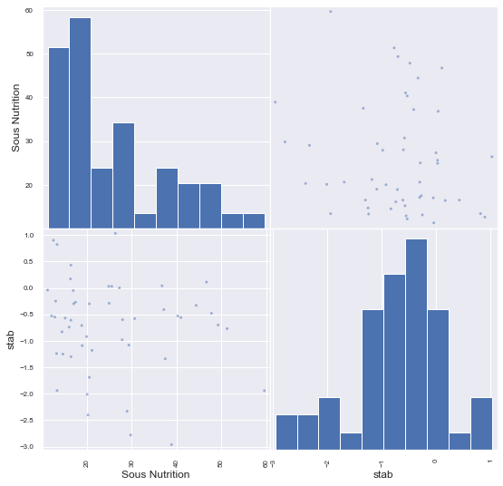

```python
# Graphique croisement deux à deux des variables
from pandas.plotting import scatter_matrix
scatter_matrix(stabPOL,figsize=(9,9))
```

```python
stabPOL.index=stabPOL['Area']
del stabPOL['Area']
```

```python
kmeans = cluster.KMeans(n_clusters=2)
kmeans.fit(stabPOL)

idk = np.argsort(kmeans.labels_)

stabPOL.columns=['Nombre','stab']
```

```
[0.67887608 0.61958048 0.63349938 0.56415976 0.57044669 0.57675814
 0.55526949 0.53296749 0.51695098]
```

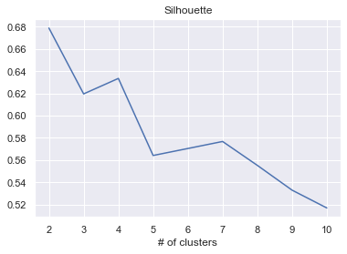

```python
## Afficher le nombre de clusters à utiliser

#utilisation de la métrique "silhouette" #faire varier le nombre de clusters de 2 à 10
res = np.arange(9,dtype="double")

for k in np.arange(9):
    km = cluster.KMeans(n_clusters=k+2)
    km.fit(stabPOL)
    res[k] = metrics.silhouette_score(stabPOL,km.labels_)
print(res)
#graphique
import matplotlib.pyplot as plt
plt.title("Silhouette")
plt.xlabel("# of clusters")
plt.plot(np.arange(2,11,1),res)
plt.show()
```

Nous trouvons d'après le graphique que le nombre de clusters idéale est 2.

```python
X=stabPOL
from sklearn.cluster import KMeans
model=KMeans(n_clusters=3)
# adapter le modèle de données

model.fit(X)
```

```
KMeans(algorithm='auto', copy_x=True, init='k-means++', max_iter=300,
       n_clusters=3, n_init=10, n_jobs=None, precompute_distances='auto',
       random_state=None, tol=0.0001, verbose=0)
```

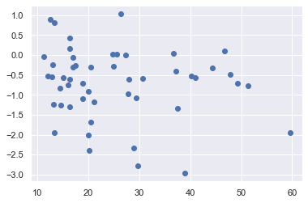

```python
plt.scatter(X.Nombre,X.stab)
```

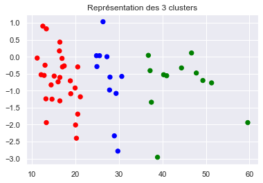

```python
colormap=np.array(['Red','green','blue'])
plt.scatter(X.Nombre, X.stab,c=colormap[model.labels_],s=40)
plt.title("Représentation des 3 clusters")
```

Nous ne trouvons pas le même resultat qu'avec Tableau.Ici Nous avons trois groupes :

```
* un premier en rouge ou la sous alimentation reste faible < 20% du pays
* un deuxième en bleu, avec une sous alimentation modérée entre 20 et 35%
* Le troisième en vert, une sous alimentation très forte > 35% de la popoulation du pays
```

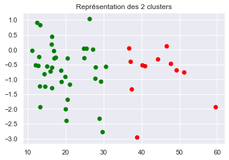

```python
model=KMeans(n_clusters=2)
# adapter le modèle de données

model.fit(X)
colormap=np.array(['Red','green','blue'])
plt.scatter(X.Nombre, X.stab,c=colormap[model.labels_],s=40)
plt.title("Représentation des 2 clusters")
```

Après avoir fait un essai sur tableau en mettant deux clusters, nous ne trouvons pas les mêmes résultats alors que la même méthode est utilisé. Une ouverture possible du sujet serai de chercher pourquoi nous ne trouvons pas les mêmes resultats.